# HRS SLE analysis Summary

Calen P. Ryan, PhD

2026-07-31

[output not shown]

# 1 Data Overview (all measures)

This section looks at the data overall, including numerical summaries and exploratory data analysis. Individual models and plots for specific SLEs in HRS follow.

## 1.1 Table of all variables (and missingness)

```r
table_all
```

| **Characteristic** | **N** | **N = 3,483**<sup>1</sup> |
| --- | --- | --- |
| Age (Years) | 3,483 | 68 (61, 77) |
| Sex (F) | 3,483 | 2,048 (59%) |
| Smoking Status | 3,462 |  |
| Never |  | 1,530 (44%) |
| Former |  | 1,541 (45%) |
| Current |  | 391 (11%) |
| Unknown |  | 21 |
| DNAmAL | 3,483 | 0.44 (0.12, 0.73) |
| methAL | 3,483 | 1.06 (1.02, 1.10) |
| methALT | 3,483 | 1.04 (1.00, 1.08) |
| sle_score1 | 2,687 | 1.00 (0.00, 3.00) |
| Unknown |  | 796 |
| sle_score2 | 3,077 | 2.00 (1.00, 3.00) |
| Unknown |  | 406 |
| sle_score3 | 2,686 | 2.00 (1.00, 3.00) |
| Unknown |  | 797 |

<sup>1</sup> Median (Q1, Q3); n (%)

Individual tables (for each SLE score) are found in Output/HRS/Tables/HRS_SLE_summary_tables.xlsx

## 1.2 Histograms of DNAm AL measures and SLE in HRS

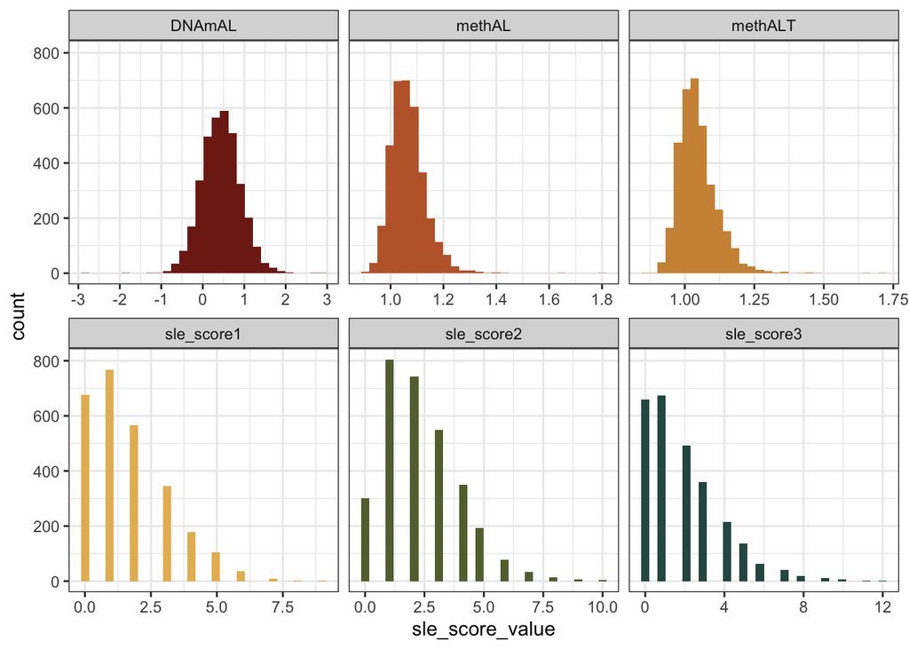

```r
histogramz
```

## 1.3 Correlation matrix of all variables

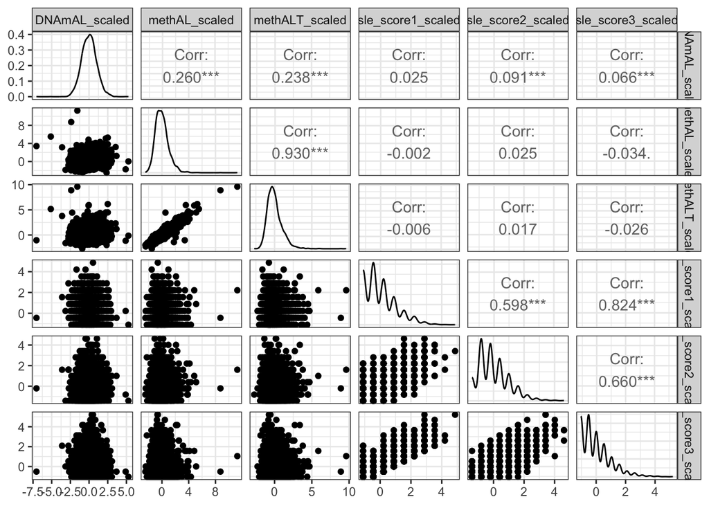

```r
ggp
```

# 2 SLE score 1

A numerical summary for SLE score 1 is found in Output/HRS/Tables/HRS_SLE_summary_tables.xlsx

## 2.1 Models comparing all three DNAm measures (DNAmAL, methAL, and methALT) to SLE Score 1.

```r
tab_model(m1, m2, m3)
```

|  | sle score 1 scaled |  |  | sle score 1 scaled |  |  | sle score 1 scaled |  |  |
| --- | --- | --- | --- | --- | --- | --- | --- | --- | --- |
| Predictors | Estimates | CI | p | Estimates | CI | p | Estimates | CI | p |
| (Intercept) | -0.93 | -1.23 – -0.63 | **<0.001** | -0.93 | -1.24 – -0.63 | **<0.001** | -0.93 | -1.23 – -0.63 | **<0.001** |
| Female | 0.20 | 0.12 – 0.28 | **<0.001** | 0.17 | 0.10 – 0.25 | **<0.001** | 0.17 | 0.10 – 0.25 | **<0.001** |
| PAGE | 0.01 | 0.01 – 0.01 | **<0.001** | 0.01 | 0.01 – 0.01 | **<0.001** | 0.01 | 0.01 – 0.01 | **<0.001** |
| smoker1213 [Former] | 0.16 | 0.08 – 0.24 | **<0.001** | 0.16 | 0.08 – 0.24 | **<0.001** | 0.16 | 0.08 – 0.24 | **<0.001** |
| smoker1213 [Current] | 0.21 | 0.08 – 0.35 | **0.002** | 0.22 | 0.09 – 0.36 | **0.001** | 0.22 | 0.09 – 0.36 | **0.001** |
| DNAmAL scaled | 0.04 | 0.00 – 0.08 | **0.045** |  |  |  |  |  |  |
| methAL scaled |  |  |  | -0.01 | -0.05 – 0.03 | 0.539 |  |  |  |
| methALT scaled |  |  |  |  |  |  | -0.01 | -0.05 – 0.03 | 0.570 |
| Observations | 2668 |  |  | 2668 |  |  | 2668 |  |  |
| R<sup>2</sup> / R<sup>2</sup> adjusted | 0.022 / 0.020 |  |  | 0.021 / 0.019 |  |  | 0.021 / 0.019 |  |  |

## 2.2 Plots of all three DNAm measures (DNAmAL, methAL, and methALT) to SLE Score 1.

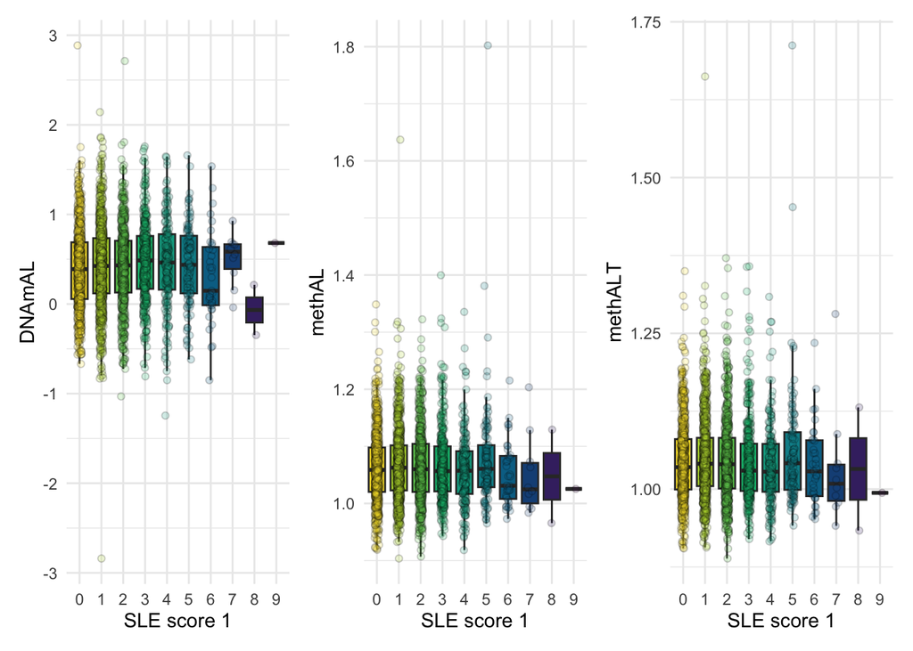

```r
sle_plots$DNAmAL_by_sle_score1 | sle_plots$methAL_by_sle_score1 | sle_plots$methALT_by_sle_score1
```

# 3 SLE score 2

A numerical summary for SLE score 2 isfound in Output/HRS/Tables/HRS_SLE_summary_tables.xlsx

## 3.1 Models comparing all three DNAm measures (DNAmAL, methAL, and methALT) to SLE Score 2.

```r
tab_model(m4, m5, m6)
```

|  | sle score 2 scaled |  |  | sle score 2 scaled |  |  | sle score 2 scaled |  |  |
| --- | --- | --- | --- | --- | --- | --- | --- | --- | --- |
| Predictors | Estimates | CI | p | Estimates | CI | p | Estimates | CI | p |
| (Intercept) | 0.02 | -0.26 – 0.29 | 0.908 | 0.04 | -0.23 – 0.32 | 0.755 | 0.03 | -0.24 – 0.31 | 0.812 |
| Female | -0.00 | -0.08 – 0.07 | 0.912 | -0.04 | -0.11 – 0.04 | 0.315 | -0.04 | -0.11 – 0.03 | 0.288 |
| PAGE | -0.00 | -0.01 – 0.00 | 0.432 | -0.00 | -0.01 – 0.00 | 0.382 | -0.00 | -0.01 – 0.00 | 0.425 |
| smoker1213 [Former] | 0.13 | 0.05 – 0.20 | **0.001** | 0.13 | 0.06 – 0.21 | **<0.001** | 0.14 | 0.06 – 0.21 | **<0.001** |
| smoker1213 [Current] | 0.30 | 0.18 – 0.42 | **<0.001** | 0.32 | 0.20 – 0.44 | **<0.001** | 0.32 | 0.20 – 0.44 | **<0.001** |
| DNAmAL scaled | 0.08 | 0.05 – 0.12 | **<0.001** |  |  |  |  |  |  |
| methAL scaled |  |  |  | 0.02 | -0.02 – 0.05 | 0.356 |  |  |  |
| methALT scaled |  |  |  |  |  |  | 0.01 | -0.03 – 0.05 | 0.550 |
| Observations | 3058 |  |  | 3058 |  |  | 3058 |  |  |
| R<sup>2</sup> / R<sup>2</sup> adjusted | 0.018 / 0.017 |  |  | 0.012 / 0.010 |  |  | 0.012 / 0.010 |  |  |

## 3.2 Plots of all three DNAm measures (DNAmAL, methAL, and methALT) to SLE Score 2.

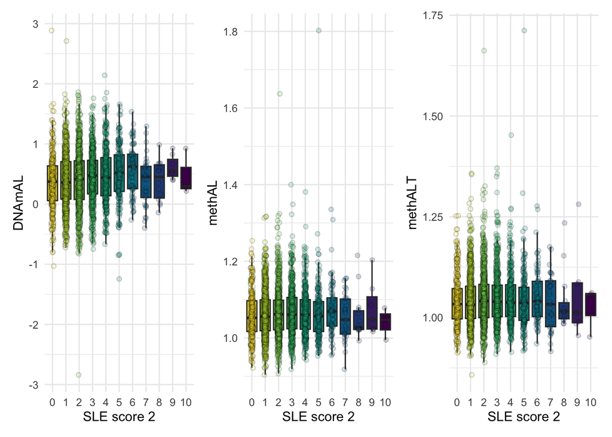

```r
sle_plots$DNAmAL_by_sle_score2 | sle_plots$methAL_by_sle_score2 | sle_plots$methALT_by_sle_score2
```

# 4 SLE score 3

A numerical summary for SLE score 3 is found in Output/HRS/Tables/HRS_SLE_summary_tables.xlsx

```r
tab_model(m7, m8, m9)
```

|  | sle score 3 scaled |  |  | sle score 3 scaled |  |  | sle score 3 scaled |  |  |
| --- | --- | --- | --- | --- | --- | --- | --- | --- | --- |
| Predictors | Estimates | CI | p | Estimates | CI | p | Estimates | CI | p |
| (Intercept) | 0.74 | 0.44 – 1.04 | **<0.001** | 0.71 | 0.40 – 1.01 | **<0.001** | 0.73 | 0.42 – 1.03 | **<0.001** |
| Female | -0.07 | -0.15 – 0.01 | 0.079 | -0.11 | -0.18 – -0.03 | **0.008** | -0.10 | -0.18 – -0.02 | **0.010** |
| PAGE | -0.01 | -0.02 – -0.01 | **<0.001** | -0.01 | -0.01 – -0.01 | **<0.001** | -0.01 | -0.01 – -0.01 | **<0.001** |
| smoker1213 [Former] | 0.15 | 0.07 – 0.23 | **<0.001** | 0.16 | 0.08 – 0.24 | **<0.001** | 0.16 | 0.08 – 0.24 | **<0.001** |
| smoker1213 [Current] | 0.20 | 0.07 – 0.34 | **0.003** | 0.22 | 0.09 – 0.36 | **0.001** | 0.22 | 0.09 – 0.35 | **0.001** |
| DNAmAL scaled | 0.05 | 0.01 – 0.09 | **0.007** |  |  |  |  |  |  |
| methAL scaled |  |  |  | -0.03 | -0.07 – 0.00 | 0.085 |  |  |  |
| methALT scaled |  |  |  |  |  |  | -0.03 | -0.07 – 0.01 | 0.160 |
| Observations | 2667 |  |  | 2667 |  |  | 2667 |  |  |
| R<sup>2</sup> / R<sup>2</sup> adjusted | 0.024 / 0.023 |  |  | 0.023 / 0.021 |  |  | 0.023 / 0.021 |  |  |

## 4.2 Plots of all three DNAm measures (DNAmAL, methAL, and methALT) to SLE Score 3.

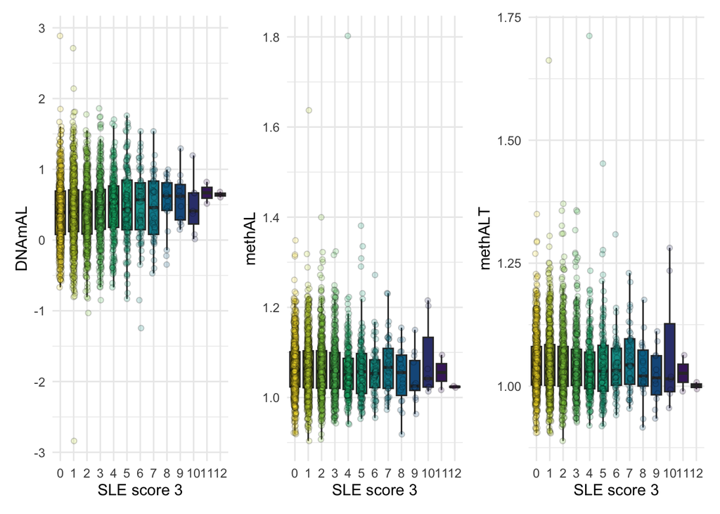

```r
sle_plots$DNAmAL_by_sle_score3 | sle_plots$methAL_by_sle_score3 | sle_plots$methALT_by_sle_score3
```